# Assignment 2

Kevin Patyk

10/28/2021

# Loading libraries, setting seed, and importing data

**Loading libraries**

```r
library(tidyverse)
library(rpart)
library(rpart.plot)
library(randomForest)
library(class)
library(caret)
library(plyr)
```

**Setting the seed for reproducibility.**

```r
set.seed(123)
```

**Importing the data.**

```r
drug <- read_csv("drug200.csv") %>%
    mutate(Sex = as.factor(Sex),
         BP = as.factor(BP),
         Cholesterol = as.factor(Cholesterol),
         Drug = as.factor(Drug))
```

# Inspecting the data

**Examining the structure of the data to make sure that all of the variable types are correct, get a general idea of how each variable looks, and to see the number of observations and variables.**

```r
str(drug)
```

```
## spec_tbl_df [200 x 6] (S3: spec_tbl_df/tbl_df/tbl/data.frame)
##  $ Age        : num [1:200] 23 47 47 28 61 22 49 41 60 43 ...
##  $ Sex        : Factor w/ 2 levels "F","M": 1 2 2 1 1 1 1 2 2 2 ...
##  $ BP         : Factor w/ 3 levels "HIGH","LOW","NORMAL": 1 2 2 3 2 3 3 2 3 2 ...
##  $ Cholesterol: Factor w/ 2 levels "HIGH","NORMAL": 1 1 1 1 1 1 1 1 1 2 ...
##  $ Na_to_K    : num [1:200] 25.4 13.1 10.1 7.8 18 ...
##  $ Drug       : Factor w/ 5 levels "drugA","drugB",..: 5 3 3 4 5 4 5 3 5 5 ...
##  - attr(*, "spec")=
##   .. cols(
##   ..   Age = col_double(),
##   ..   Sex = col_character(),
##   ..   BP = col_character(),
##   ..   Cholesterol = col_character(),
##   ..   Na_to_K = col_double(),
##   ..   Drug = col_character()
##   .. )
##  - attr(*, "problems")=<externalptr>
```

**Inspecting the first 6 observations of the data to make sure that there are no issues with the column names and to see if it was imported correctly.**

```r
head(drug)
```

```
## # A tibble: 6 x 6
##     Age Sex   BP     Cholesterol Na_to_K Drug
##   <dbl> <fct> <fct>  <fct>         <dbl> <fct>
## 1    23 F     HIGH   HIGH          25.4  DrugY
## 2    47 M     LOW    HIGH          13.1  drugC
## 3    47 M     LOW    HIGH          10.1  drugC
## 4    28 F     NORMAL HIGH           7.80 drugX
## 5    61 F     LOW    HIGH          18.0  DrugY
## 6    22 F     NORMAL HIGH           8.61 drugX
```

**Checking for the presence of missing values.**

```r
any(is.na(drug))
```

```
## [1] FALSE
```

**Obtaining basic descriptive statistics and frequency distributions.**

```r
summary(drug)
```

```
##       Age        Sex          BP     Cholesterol     Na_to_K          Drug
##  Min.   :15.00   F: 96   HIGH  :77   HIGH  :103   Min.   : 6.269   drugA:23
##  1st Qu.:31.00   M:104   LOW   :64   NORMAL: 97   1st Qu.:10.445   drugB:16
##  Median :45.00           NORMAL:59                Median :13.937   drugC:16
##  Mean   :44.31                                    Mean   :16.084   drugX:54
##  3rd Qu.:58.00                                    3rd Qu.:19.380   DrugY:91
##  Max.   :74.00                                    Max.   :38.247
```

**The `summary()` function does not display standard deviations, so we will do it manually.**

```r
drug %>%
  select_if(is.numeric) %>%
  summarise_all(sd)
```

```
## # A tibble: 1 x 2
##     Age Na_to_K
##   <dbl>   <dbl>
## 1  16.5    7.22
```

**While checking the summary of the dataset, I noticed that there is an inconsistency in the levels of the drug types. In particular, all of the drug types are labeled like “drugA”, “drugB”, “drugC”, and “drugX”, while the last is labeled as “DrugY”. I decided to fix this just for the sake of consistency.**

```r
#first, convert drug back to a character
drug$Drug <- as.character(drug$Drug)
#second, replace values with "DrugY" to "drugY"
drug$Drug[drug$Drug == "DrugY"] <- "drugY"
#then, convert it back to factor
drug$Drug <- as.factor(drug$Drug)
```

**Examining histograms for the numeric variables (age and sodium to potassium ratio).**

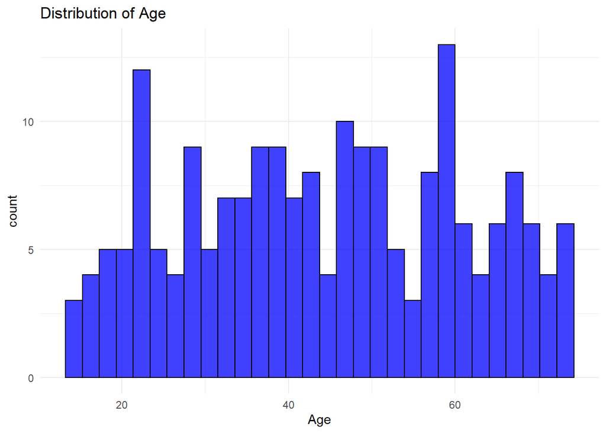

```r
#histogram for age
drug %>%
  ggplot(aes(x = Age)) +
  geom_histogram(fill = "blue", color = "black", alpha = 0.75) +
  labs(title = "Distribution of Age") +
  theme_minimal()
```

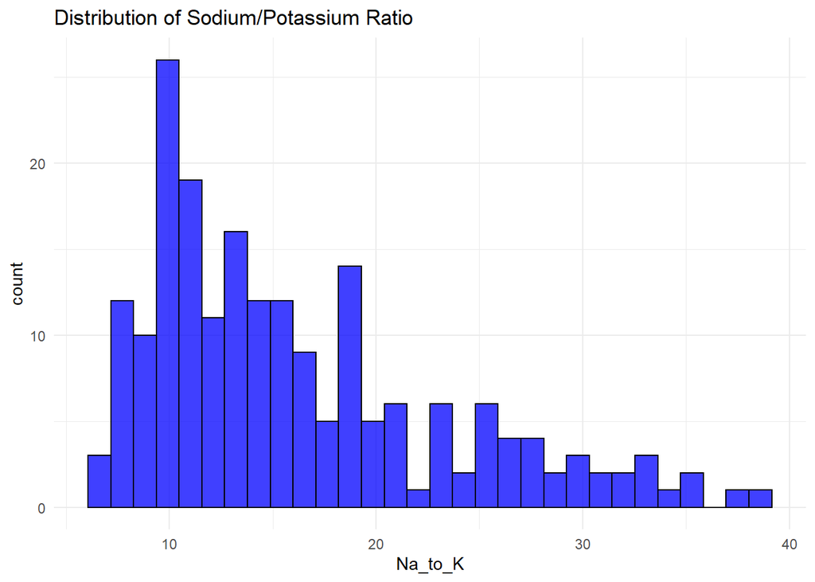

```r
#histogram for sodium to potassium ratio
drug %>%
  ggplot(aes(x = Na_to_K)) +
  geom_histogram(fill = "blue", color = "black", alpha = 0.75) +
  labs(title = "Distribution of Sodium/Potassium Ratio") +
  theme_minimal()
```

**Visualizing other elements of the dataset.**

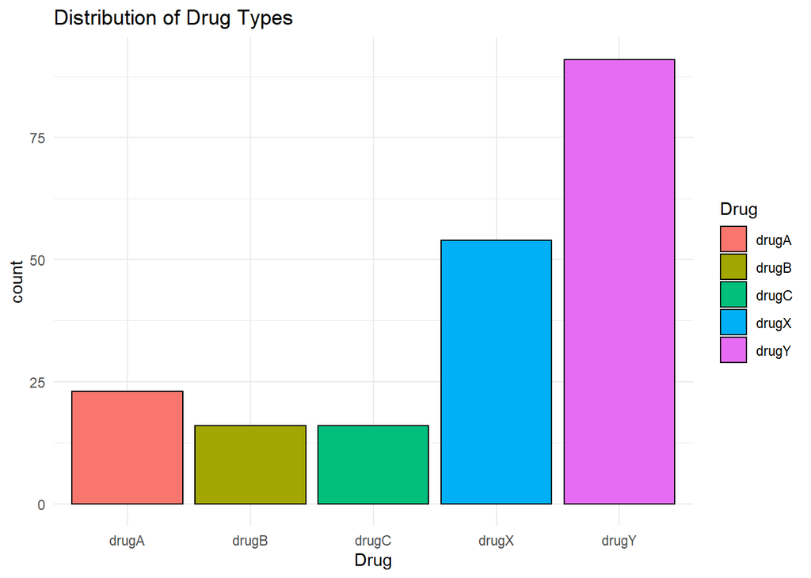

```r
drug %>%
  ggplot(aes(x = Drug)) +
  geom_bar(aes(fill = Drug), color = "black") +
  ggtitle("Distribution of Drug Types") +
  theme_minimal()
```

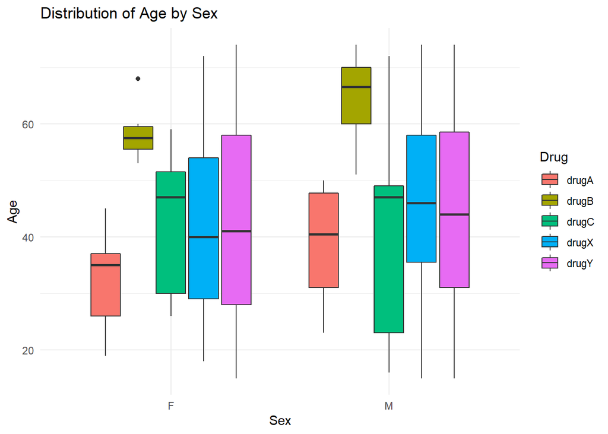

```r
drug %>%
  ggplot(aes(x = Sex, y = Age)) +
  geom_boxplot(aes(fill = Drug)) +
  ggtitle("Distribution of Age by Sex") +
  theme_minimal()
```

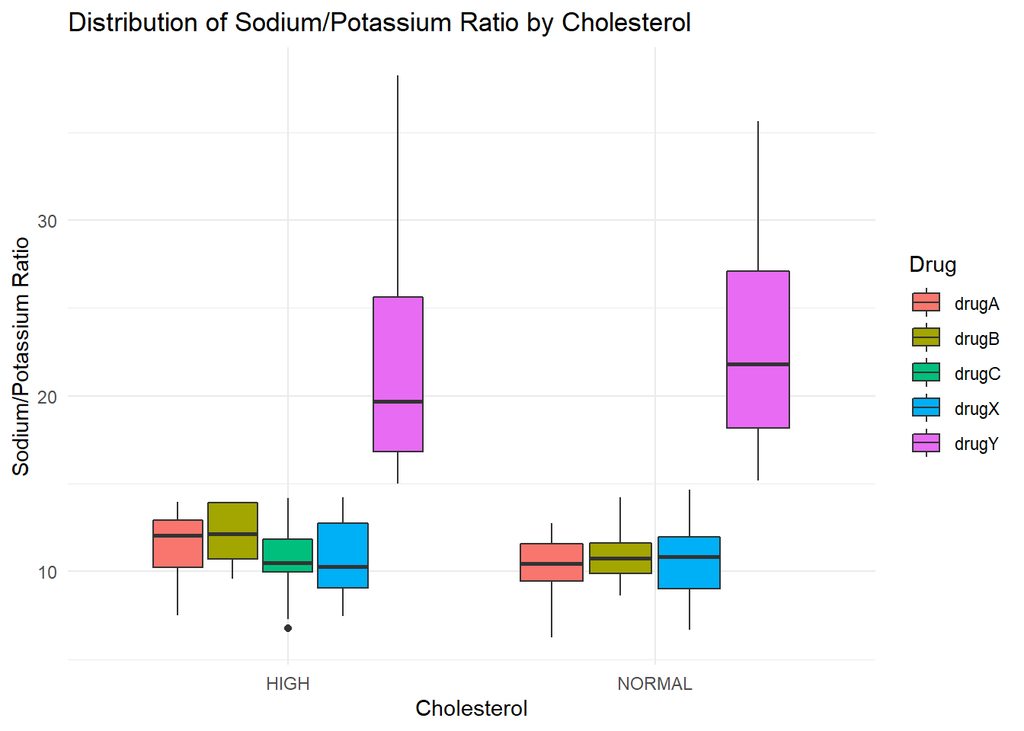

```r
drug %>%
  ggplot(aes(x = Cholesterol, y = Na_to_K)) +
    geom_boxplot(aes(fill = Drug)) +
  ggtitle("Distribution of Sodium/Potassium Ratio by Cholesterol") +
  ylab("Sodium/Potassium Ratio") +
  theme_minimal()
```

**Examining the separation between classes in the dataset.**

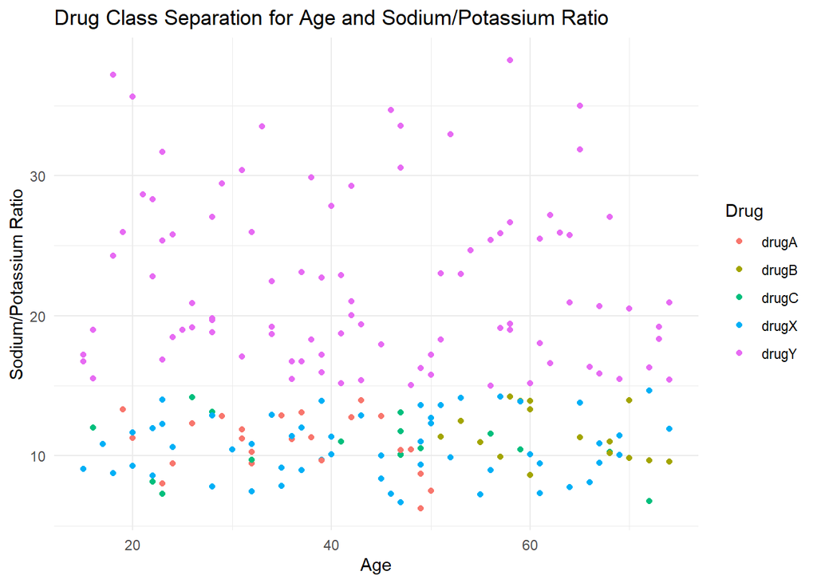

```r
drug %>%
  ggplot(aes(x = Age, y = Na_to_K)) +
  geom_point(aes(color = Drug)) +
  ggtitle("Drug Class Separation for Age and Sodium/Potassium Ratio") +
  ylab("Sodium/Potassium Ratio") +
  theme_minimal()
```

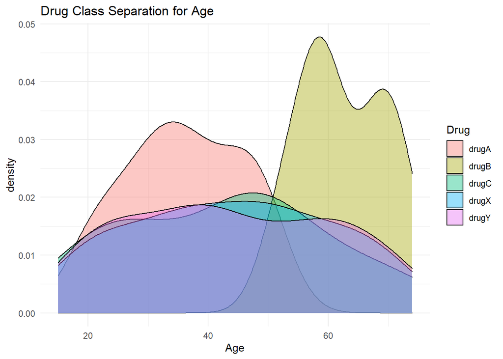

```r
drug %>%
  ggplot(aes(x = Age)) +
  geom_density(aes(fill = Drug), alpha = 0.4) +
  ggtitle("Drug Class Separation for Age") +
  theme_minimal()
```

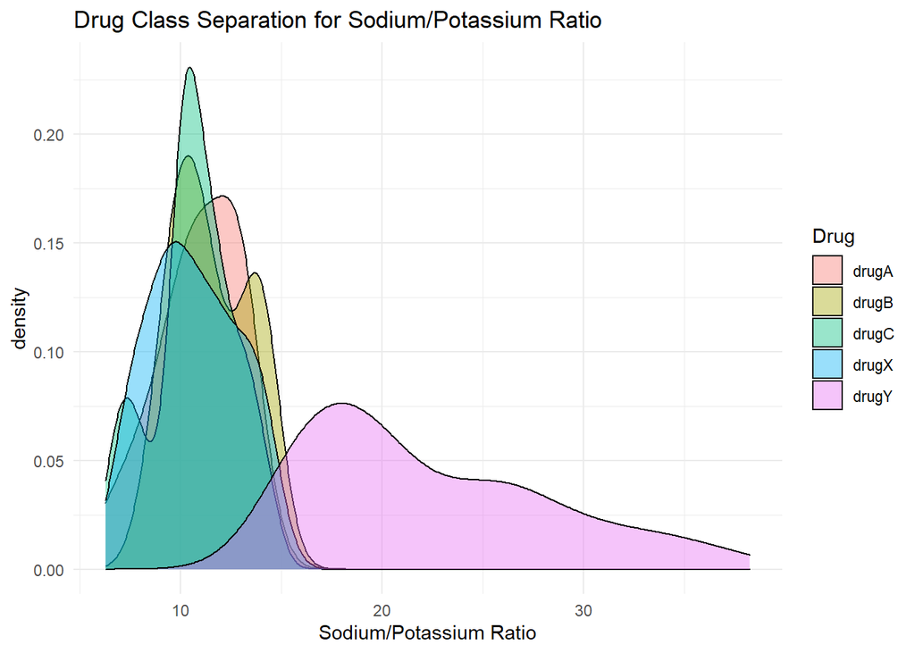

```r
drug %>%
  ggplot(aes(x = Na_to_K)) +
  geom_density(aes(fill = Drug), alpha = 0.4)+
  ggtitle("Drug Class Separation for Sodium/Potassium Ratio") +
  xlab("Sodium/Potassium Ratio") +
  theme_minimal()
```

## Describing the dataset

This dataset was obtained from [Kaggle](https://www.kaggle.com/prathamtripathi/drug-classification). It contains 200 observations and 6 variables. The 6 variables are Age, Sex (male or female), Blood Pressure Levels (high, low, or normal), Cholesterol (high or normal), Na_to_K, which stands for sodium to potassium ratio in the blood, and Drug Type (drugA, drugB, drugC, drugX, or drugY). The target feature is Drug Type, with all other variables serving as feature sets; this is a classification problem. There are no missing data. The mean age for participants is 44.31 (SD = 16.54) and the mean sodium to potassium ratio in the blood is 16.08 (SD = 7.22). The age variable is not normally distributed and the sodium to potassium distribution is positively skewed.

A majority of the participants are male (52%) and the rest are female (48%). Many of the participants had high blood pressure levels (39%), followed by low blood pressure levels (32%) and finally normal (29%). Over half of the participants (52%) had high cholesterol levels while the rest were normal (48%). For drug type, drugY was the most prevalent (46%), followed by drugX (27%), then by drugA (11%), and finally by drugB/drugC (both 8%). Ages within genders were similarly distributed, with the drugB group having the highest average age. For high and normal levels of cholesterol, the average sodium to potassium ratio was the highest for drugY. The separation between the groups was not particularly strong. For age, the strongest separation occurred between drugA and drugB, while for the sodium to potassium ratio, only drugY shows strong separation.

# Implementing a simple model

For the simple model, we will be using K-nearest neighbors (KNN) for classification.

**Prior to running the KNN model, we should scale the predictor variables. This is so that the algorithm will not be affected by the magnitude of different variables. The variables will be scaled using standard scaling:**

$$x_i = \frac{x_i - \bar{x}} {\sigma}$$

```r
#scaling the variables
drug_scaled <- drug %>%
  mutate(
    Age = scale(Age),
    Sex = scale(as.numeric(Sex)),
    BP = scale(as.numeric(BP)),
    Cholesterol = scale(as.numeric(Cholesterol)),
    Na_to_K = scale(Na_to_K)
)

#double checking to make sure that it worked properly
head(drug_scaled)
```

```
## # A tibble: 6 x 6
##   Age[,1] Sex[,1] BP[,1] Cholesterol[,1] Na_to_K[,1] Drug
##     <dbl>   <dbl>  <dbl>           <dbl>       <dbl> <fct>
## 1  -1.29   -1.04  -1.11           -0.968       1.28  drugY
## 2   0.162   0.958  0.110          -0.968      -0.414 drugC
## 3   0.162   0.958  0.110          -0.968      -0.826 drugC
## 4  -0.986  -1.04   1.33           -0.968      -1.15  drugX
## 5   1.01   -1.04   0.110          -0.968       0.271 drugY
## 6  -1.35   -1.04   1.33           -0.968      -1.04  drugX
```

**Splitting the data into a training and testing set. We will take 80% of the observations for the training set and 20% of the observations for the testing set.**

```r
drug_scaled <- drug_scaled %>%
  mutate(split = sample(rep(c("train", "test"), times = c(160, 40))))

drug_train <- drug_scaled %>%
  filter(split == "train") %>%
  dplyr::select(-split)

drug_test <- drug_scaled %>%
  filter(split == "test") %>%
  dplyr::select(-split)
```

**Fitting the KNN model on the training data. We will be using 10-fold cross validation in order to determine the best value for K. This will be repeated 10 times. We will be expanding the values for K to go from 1 to 20.**

```r
knn_cv <- trainControl(method = "repeatedcv", number = 10, repeats = 10)

knn_mod <- caret::train(Drug ~ . , data = drug_train, method = "knn", trControl = knn_cv, tuneGrid = expand.grid(k = 1:20))

knn_mod
```

```
## k-Nearest Neighbors
##
## 160 samples
##   5 predictor
##   5 classes: 'drugA', 'drugB', 'drugC', 'drugX', 'drugY'
##
## No pre-processing
## Resampling: Cross-Validated (10 fold, repeated 10 times)
## Summary of sample sizes: 145, 144, 144, 143, 143, 143, ...
## Resampling results across tuning parameters:
##
##   k   Accuracy   Kappa
##    1  0.8912611  0.8495502
##    2  0.8292070  0.7629148
##    3  0.8593176  0.8050120
##    4  0.7920273  0.7106021
##    5  0.7644660  0.6721092
##    6  0.7432731  0.6422858
##    7  0.7462512  0.6434716
##    8  0.7448354  0.6389684
##    9  0.7248218  0.6119666
##   10  0.7187109  0.5979237
##   11  0.7012958  0.5705424
##   12  0.6995109  0.5645566
##   13  0.6972933  0.5550070
##   14  0.7017774  0.5587414
##   15  0.7060473  0.5611602
##   16  0.7135430  0.5713503
##   17  0.7263401  0.5914362
##   18  0.7320505  0.5984670
##   19  0.7273113  0.5882704
##   20  0.7453757  0.6148766
##
## Accuracy was used to select the optimal model using the largest value.
## The final value used for the model was k = 1.
```

**Creating predictions and assessing the out-of-sample accuracy of the KNN model.**

```r
model_knn <-knn(train = drug_train[-6], test = drug_test[-6], cl = drug_train$Drug, k = 1)
confusionMatrix(drug_test$Drug, model_knn)
```

```
## Confusion Matrix and Statistics
##
##           Reference
## Prediction drugA drugB drugC drugX drugY
##      drugA     4     0     0     0     0
##      drugB     0     2     0     0     0
##      drugC     0     0     2     0     0
##      drugX     0     0     0    10     0
##      drugY     0     1     3     0    18
##
## Overall Statistics
##
##                Accuracy : 0.9
##                  95% CI : (0.7634, 0.9721)
##     No Information Rate : 0.45
##     P-Value [Acc > NIR] : 3e-09
##
##                   Kappa : 0.8507
##
##  Mcnemar's Test P-Value : NA
##
## Statistics by Class:
##
##                      Class: drugA Class: drugB Class: drugC Class: drugX
## Sensitivity                   1.0       0.6667       0.4000         1.00
## Specificity                   1.0       1.0000       1.0000         1.00
## Pos Pred Value                1.0       1.0000       1.0000         1.00
## Neg Pred Value                1.0       0.9737       0.9211         1.00
## Prevalence                    0.1       0.0750       0.1250         0.25
## Detection Rate                0.1       0.0500       0.0500         0.25
## Detection Prevalence          0.1       0.0500       0.0500         0.25
## Balanced Accuracy             1.0       0.8333       0.7000         1.00
##                      Class: drugY
## Sensitivity                1.0000
## Specificity                0.8182
## Pos Pred Value             0.8182
## Neg Pred Value             1.0000
## Prevalence                 0.4500
## Detection Rate             0.4500
## Detection Prevalence       0.5500
## Balanced Accuracy          0.9091
```

- As, we can see that the overall accuracy of the model is 90%. This means that 10% of the observations were misclassified. This is very good for a relatively simple algorithm.
- The sensitivity for drugA, drugX, and drugY is 100%, meaning that if the observation is in one of those drug groups, the probability that the model will detect this is 100%. For drugB, the sensitivity is 67%, so if the observation is in drugB, there is a 67% chance that the model will detect this. For drugC, the sensitivity is 40%, so if the observation is in group drugB, there is a 40% chance that the model will detect this.
- The specificity for drugA, drugB, drugC, and drugX is 100%, meaning that if the observation is not in one of these drug groups, there is a 100% chance that the model will not detect this. For drugY, the specificity is 82%, so if the observation is not in group drugY, there is an 82% chance that the model will detect this.
- The positive predictive value (PPV) for drugA, drugB, drugC, and drugX is 100%, so if the observation is predicted to be in one of these groups, there is a 100% chance that they will actually be in one of these drug groups. The PPV for drugY is 82%, so so if the observation is predicted to be in this group, there is an 82% that they will actually be in this group.
- The negative predictive value (NPV) for drugA, drugX, and drugY is 100%, so if the observation is not predicted to be in one of these drug groups, there is a 100% chance that they will actually not be in one of these drug groups. The NPV for drugB is 97%, so if the observation is not predicted to be in group drugB, there is a 97% chance that they will actually not be in this drug group. The NPV for drugC is 92%, so if the observation is not predicted to be in group drugB, there is a 92% chance that they will actually not be in this drug group.

**Visualizing our predictions made from the KNN model.**

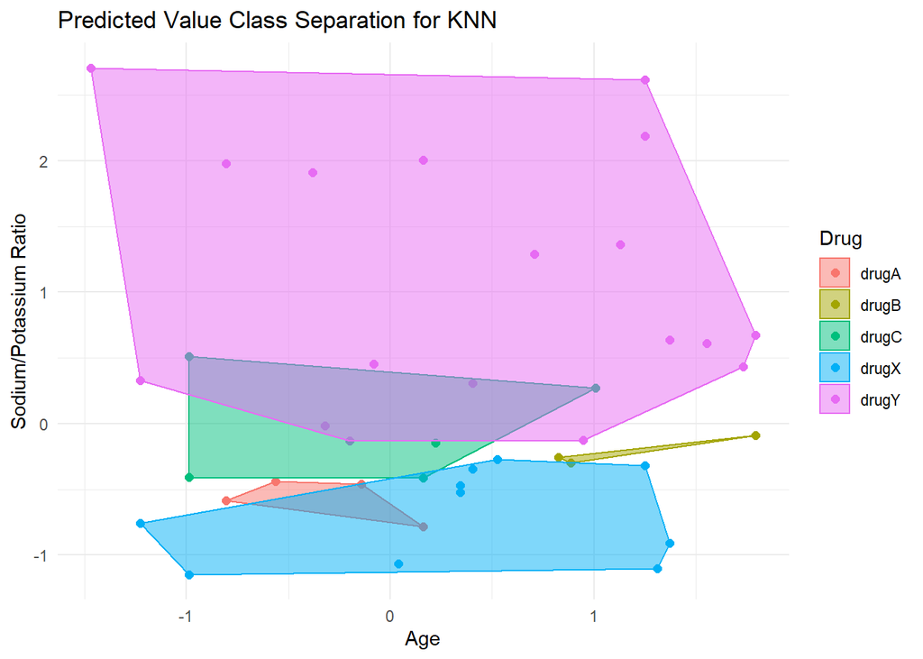

```r
#creating a new data frame for plotting
plot_knn <- data.frame(drug_test[, 1:5], Drug = model_knn)
plot_knn2 <- data.frame(x = plot_knn$Na_to_K,
                        y = plot_knn$Age,
                        Drug = plot_knn$Drug)

#finding the hulls for the polygons that will go over the points
find_hull <- function(df) df[chull(df$x, df$y), ]
hulls <- ddply(plot_knn2, .variables = "Drug", .fun = find_hull)

#plotting the predicted values of KNN
ggplot(plot_knn, aes(Na_to_K, Age, color = Drug, fill = Drug)) +
  geom_point(size = 2) +
  geom_polygon(data = hulls, aes(x,y), alpha = 0.5) +
  xlab("Sodium/Potassium Ratio") +
  ggtitle("Predicted Value Class Separation for KNN") +
  theme_minimal() +
  coord_flip()
```

# Implementing a more complex model

For the more complex model, a random forest will be used.

In the previous section, the data was split into training and testing, so it will not be done here. The classes for the outcome variable, `Drug`, are imbalanced, so I tried doing 2 random forests with stratification and sample size.

**First, fitting the random forest on the training data.**

```r
#creating a table of the class imbalance
table(drug_train$Drug)
```

```
##
## drugA drugB drugC drugX drugY
##    19    14    14    44    69
```

```r
#obtaining the count from the smallest class
nmin <- sum(drug_train$Drug == "drugB")

#running the first random forest with stratification and sample size
rf_train <- randomForest(Drug ~ .,
                         data = drug_train,
                         strata = drug_train$Drug,
                         sampsize = rep(nmin, 5))

#setting the training specifications
ctrl <- trainControl(method = "cv",
                     classProbs = TRUE,
                     summaryFunction = multiClassSummary)

#running the second random forest with stratification and sample size
rfDownsampled <- train(Drug ~ ., data = drug_train,
                       method = "rf",
                       ntree = 1500,
                       tuneLength = 5,
                       trControl = ctrl,
                       strata = drug_train$Drug,
                       sampsize = rep(nmin, 5))
```

**Fitting the random forest on the testing data and assessing the accuracy of the method for the first random forest with stratification and sampling.**

```r
pred_rf1 <- predict(rf_train, newdata = drug_test)
confusionMatrix(drug_test$Drug, pred_rf1)
```

```
## Confusion Matrix and Statistics
##
##           Reference
## Prediction drugA drugB drugC drugX drugY
##      drugA     4     0     0     0     0
##      drugB     0     2     0     0     0
##      drugC     0     0     2     0     0
##      drugX     0     0     0    10     0
##      drugY     0     0     0     0    22
##
## Overall Statistics
##
##                Accuracy : 1
##                  95% CI : (0.9119, 1)
##     No Information Rate : 0.55
##     P-Value [Acc > NIR] : 4.116e-11
##
##                   Kappa : 1
##
##  Mcnemar's Test P-Value : NA
##
## Statistics by Class:
##
##                      Class: drugA Class: drugB Class: drugC Class: drugX
## Sensitivity                   1.0         1.00         1.00         1.00
## Specificity                   1.0         1.00         1.00         1.00
## Pos Pred Value                1.0         1.00         1.00         1.00
## Neg Pred Value                1.0         1.00         1.00         1.00
## Prevalence                    0.1         0.05         0.05         0.25
## Detection Rate                0.1         0.05         0.05         0.25
## Detection Prevalence          0.1         0.05         0.05         0.25
## Balanced Accuracy             1.0         1.00         1.00         1.00
##                      Class: drugY
## Sensitivity                  1.00
## Specificity                  1.00
## Pos Pred Value               1.00
## Neg Pred Value               1.00
## Prevalence                   0.55
## Detection Rate               0.55
## Detection Prevalence         0.55
## Balanced Accuracy            1.00
```

**Fitting the random forest on the testing data and assessing the accuracy of the method for the second random forest with stratification and sampling.**

```r
pred_rf2 <- predict(rfDownsampled, newdata = drug_test)
confusionMatrix(drug_test$Drug, pred_rf2)
```

```
## Confusion Matrix and Statistics
##
##           Reference
## Prediction drugA drugB drugC drugX drugY
##      drugA     4     0     0     0     0
##      drugB     0     2     0     0     0
##      drugC     0     0     2     0     0
##      drugX     0     0     0    10     0
##      drugY     0     0     0     0    22
##
## Overall Statistics
##
##                Accuracy : 1
##                  95% CI : (0.9119, 1)
##     No Information Rate : 0.55
##     P-Value [Acc > NIR] : 4.116e-11
##
##                   Kappa : 1
##
##  Mcnemar's Test P-Value : NA
##
## Statistics by Class:
##
##                      Class: drugA Class: drugB Class: drugC Class: drugX
## Sensitivity                   1.0         1.00         1.00         1.00
## Specificity                   1.0         1.00         1.00         1.00
## Pos Pred Value                1.0         1.00         1.00         1.00
## Neg Pred Value                1.0         1.00         1.00         1.00
## Prevalence                    0.1         0.05         0.05         0.25
## Detection Rate                0.1         0.05         0.05         0.25
## Detection Prevalence          0.1         0.05         0.05         0.25
## Balanced Accuracy             1.0         1.00         1.00         1.00
##                      Class: drugY
## Sensitivity                  1.00
## Specificity                  1.00
## Pos Pred Value               1.00
## Neg Pred Value               1.00
## Prevalence                   0.55
## Detection Rate               0.55
## Detection Prevalence         0.55
## Balanced Accuracy            1.00
```

Looks like both have the exactly same result with 100% accuracy. So, for both models, the conclusions are:

- The accuracy of our random forest model is 100%, meaning that all of the observations were correctly classified and there were no misclassifications.
- The sensitivity for all drug groups is 100%, meaning that if the observation is in one of those drug groups, the probability that the model will detect this is 100%.
- The specificity for all drug groups is 100%, meaning that if the observation is not in one of these drug groups, there is a 100% chance that the model will not detect this.
- The PPV for all drug groups is 100%, so if the observation is predicted to be in one of these groups, there is a 100% chance that they will actually be in one of these drug groups.
- The NPV for all drug groups is 100%, so if the observation is not predicted to be in one of these drug groups, there is a 100% chance that they will actually not be in one of these drug groups.